# Disciplina IAED UNESP - COVID-19 no município de Bauru

Plinio Leme

22/02/2021

## 1. Introdução

Esse relatório apresenta informações relativas à pandemia de COVID-19 no município de Bauru. São destacadas as diferentes formas que a doença impactou os moradores da cidade. Explorando o genero, a idade, as comorbidades e os tipos de leitos foi possível ver essas diferenças.

## 2. Análise Exploratória dos Dados

Na figura 1 temos as mortes por genero Masculino e Feminino, a maior parte dos mortos é do sexo mascuilino, possivelmente isso esta relacionado com as comorbidades(Ver figura 4).

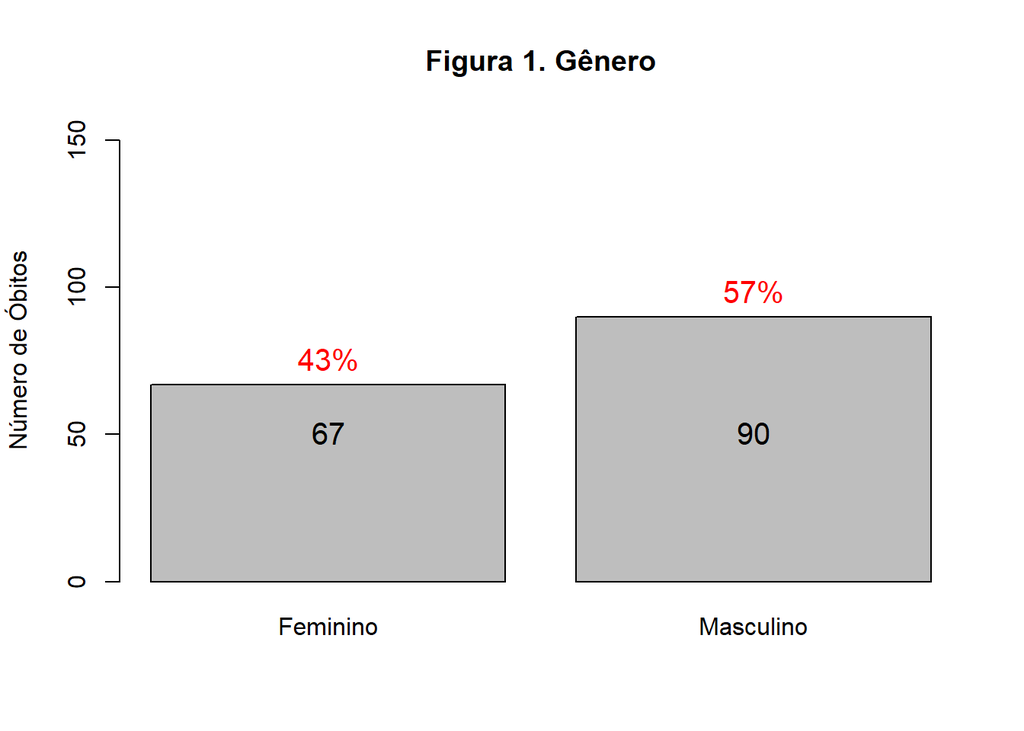

Em relação ao tipo de hospitalização não foi possível tirar muitas conclusões, os números são muito semelhantes apesar de uma leve vantagem das hospitalizações privadas. Os dados precisam de mais contextualização para que seja tirada qualquer conclusão, como a proporção de leitos publicos e privados na cidade.

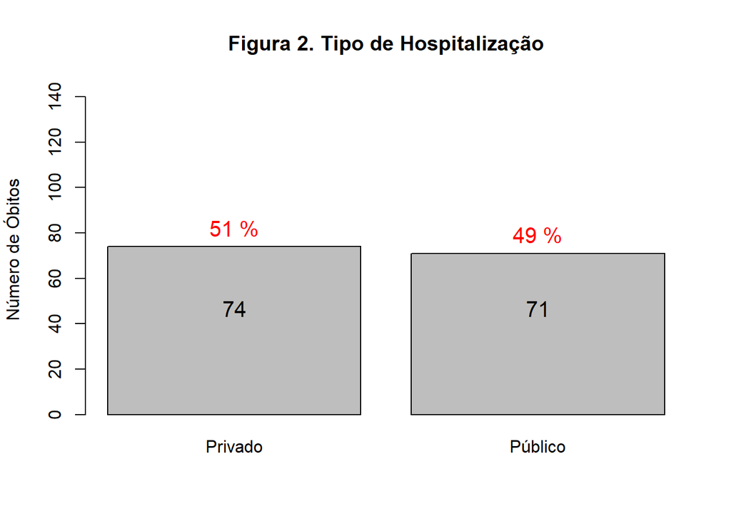

É amplamente difundido que a maior mortalidade da doença se da apartir dos 60 anos. A figura 3 confirma essa informação, mostrando um número maior de mortos dentro dessa faixa etaria.

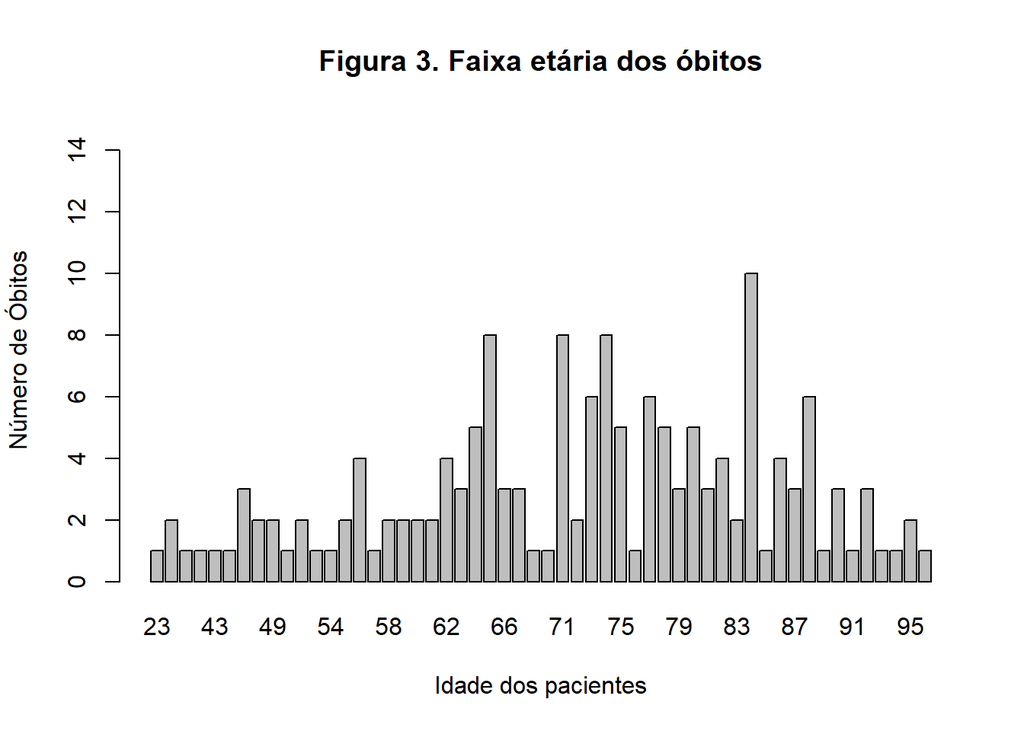

Também alinhado com o restante do país, problemas cronicos de saude tem uma relação forte com a mortalidade.

Na figura 4 vemos como a diabetes e problemas cardiorespiratórios se destacam como principais comorbidades.

```
##
##        cardiopatia câncer de próstata     câncer de mama             câncer
##                 68                  1                  1                  1
##               asma  artrite rematóide       angioplastia          Alzheimer
##                  5                  1                  1                  3
```

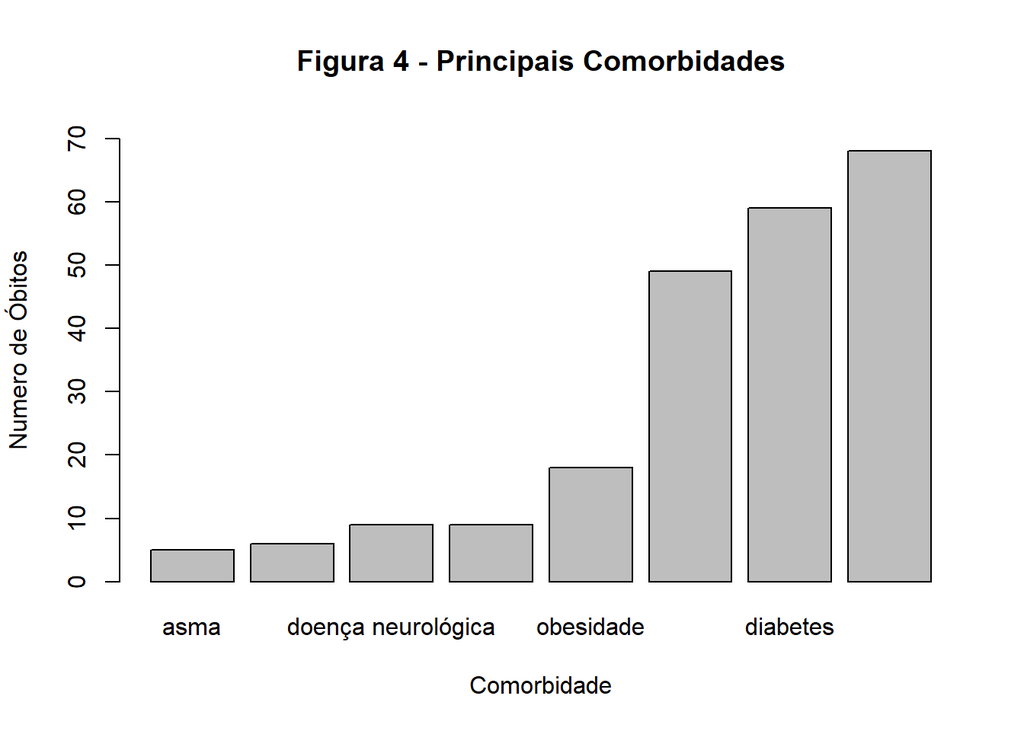